# Math 365 / Comp 365: Homework 3

### *Please bring a stapled hard copy of your answers to class*

### Problem 1

In class, we showed how to construct a sequence of unit lower-triangular matrices $\{L_{k}\}_{k=1,2,\ldots,n-1}$ of the form

$$L_{k}=\begin{pmatrix} 1 & & & & & \\
& \ddots & & & & \\
& & 1 & & & \\
& & -\ell_{k+1,k} & 1 & & \\
& & \ddots & & \ddots & \\
& & -\ell_{n,k} & & & 1
\end{pmatrix}~, \hbox{ where } \ell_{j,k}=\frac{A_{j,k}}{A_{k,k}},~\hbox{ for } k\leq j \leq n,$$

such that

$$L_{n-1} L_{n-2} \ldots L_{2} L_{1} A = U,$$

with $U$ being an upper-triangular matrix. We now want to show in two steps that

$$L:= L_{1}^{-1} L_{2}^{-1} \ldots L_{n-2}^{-1} L_{n-1}^{-1}$$

is a unit lower-triangular matrix.

1. Show that

$$L_{k}^{-1} = \begin{pmatrix} 1 & & & & & \\
& \ddots & & & & \\
& & 1 & & & \\
& & \ell_{k+1,k} & 1 & & \\
& & \ddots & & \ddots & \\
& & \ell_{n,k} & & & 1
\end{pmatrix}.$$

**Hint**: Start by showing that $L_k=I-\ell_k e_k^{T}$, where $e_k$ is an $n \times 1$ vector with a 1 in the $k^{th}$ entry, and zeros elsewhere, and

$$\ell_k = \begin{pmatrix} 0 \\ \vdots \\ 0 \\ \ell_{k+1,k} \\ \vdots \\ \ell_{n,k} \end{pmatrix}.$$

2. Now show that

$$L:= L_{1}^{-1} L_{2}^{-1} \ldots L_{n-2}^{-1} L_{n-1}^{-1} = \begin{pmatrix} 1 & & & & \\
\ell_{21} & 1 & & & \\
\ell_{31} & \ell_{32} & 1 & & \\
\vdots & \vdots & \ddots & \ddots & \\
\ell_{n1} & \ell_{n2} & \cdots & \ell_{n,n-1} & 1 \\
\end{pmatrix}$$

### Solution:

1. Note that $e_k^T \ell_k=0$. Therefore, we have:

$$(I+\ell_k e_k^T)L_k = (I+\ell_k e_k^T)(I-\ell_k e_k^T)=I-\ell_k e_k^T \ell_k e_k^T = I,$$

and we conclude that

$$L_k^{-1}=I+\ell_k e_k^T=\begin{pmatrix} 1 & & & & & \\
& \ddots & & & & \\
& & 1 & & & \\
& & \ell_{k+1,k} & 1 & & \\
& & \ddots & & \ddots & \\
& & \ell_{n,k} & & & 1
\end{pmatrix}.$$

2. Using the result of (a), we have

$$L_{k}^{-1} L_{k+1}^{-1} = (I+\ell_k e_k^T)(I+\ell_{k+1} e_{k+1}^T) = I + \ell_k e_k^T + \ell_{k+1} e_{k+1}^T + \ell_k e_k^T \ell_{k+1} e_{k+1}^T=I + \ell_k e_k^T + \ell_{k+1} e_{k+1}^T,$$

as $e_k^T \ell_{k+1}=0$. In fact, $e_k^T \ell_{j}=0$ for $j \geq k$, and so we can repeat the process until we reach

$$L:= L_{1}^{-1} L_{2}^{-1} \ldots L_{n-2}^{-1} L_{n-1}^{-1} =
I + \ell_1 e_1^T + \ell_{2} e_{2}^T + \ldots + \ell_{n-1} e_{n-1}^T
=
\begin{pmatrix} 1 & & & & \\
\ell_{21} & 1 & & & \\
\ell_{31} & \ell_{32} & 1 & & \\
\vdots & \vdots & \ddots & \ddots & \\
\ell_{n1} & \ell_{n2} & \cdots & \ell_{n,n-1} & 1 \\
\end{pmatrix}.$$

### Problem 2: An application in heat transfer

*This problem is from Section 2.5, page 131 of Linear Algebra and Its Applications, by David Lay, the textbook many of you used for MATH 236.*

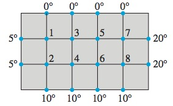

An important concern in the study of heat transfer is to determine the steady-state temperature distribution of a thin plate when the temperature around the boundary is known. Assume the plate shown in the figure above represents a cross section of a metal beam, with negligible heat flow in the direction perpendicular to the plate. Let the variables $x_1, x_2, \ldots, x_8$ denote the temperatures at nodes 1 through 8 in the picture. In steady state, the temperature at a node is approximately equal to the average of the four nearest nodes (to the left, above, right, below).

1. The solution to the approximate steady-state heat flow problem for this plate can be written as a system of linear equations $Ax=b$, where $x=[x_1, x_2, \ldots, x_8]$ is the vector of temperatures at nodes 1 through 8. Find the $8 \times 8$ matrix $A$ and the vector $b$. Hint: $A$ should be a banded matrix with many zeros in the top right and bottom left parts of $A$.
2. Use your function from Exercise 1 to perform an LU factorization of $A$. Do you notice anything special about the structures of $L$ and $U$?
3. Once you have an LU factorization for a matrix $A$, you need to do the two-step procedure to complete the back substitution to solve $Ax=b$. Below is code for that. Make sure you understand what the code is doing, and then use it to find the steady-state temperatures at nodes 1 through 8.

```r
mySolve=function(L,U,b,tol=1e-10){

  n=nrow(L)

  # First solve Ly=b
  y = rep(0,n)        # pre-allocate a vector y with 0s in it.
  if(abs(L[1,1])<tol) stop('There is a zero on the diagonal of L')
  y[1] = b[1]/L[1,1]  # Fill in the 1st value of y
  for (j in 2:n ) {
    if(abs(L[j,j])<tol) stop('There is a zero on the diagonal of L')
    y[j] = (b[j] - L[j,1:(j-1)]%*%y[1:(j-1)])/L[j,j]
  }

  # Then solve Ux=y
  x = rep(0,n)        # pre-allocate a vector x with 0s in it.
  if(abs(U[n,n])<tol) stop('There is a zero on the diagonal of U')
  x[n] = y[n]/U[n,n]  # Fill in the nth value of x
  for (j in (n-1):1 ) {
    if(abs(U[j,j])<tol) stop('There is a zero on the diagonal of U')
    x[j] = (y[j] - U[j,(j+1):n]%*%x[(j+1):n])/U[j,j]
  }
  return(x)
}
```

Make sure you understand what the code is doing, and then use it to find the steady-state temperatures at nodes 1 through 8.

4. The temperature on the right-hand side of the plate was measured incorrectly. It is actually 30 degrees. Find the new steady-state temperatures. Hint: you should not do another LU factorization!
5. Use the R function `solve(A)` to compute $A^{-1}$. Note that $A^{-1}$ is a **dense** matrix (without many zeros). When $A$ is large, $L$ and $U$ can be stored in much less space than $A^{-1}$. This fact is another reason for preferring the LU factorization of $A$ to $A^{-1}$ itself.

**Solution**

1. Notice that the equations will follow the form:
   $$\begin{array}{l}
   x_1=1/4(0+5+x_2+x_3)\\
   x_2=1/4(5+10+x_1+x_4)\\
   \vdots\\
   x_8=1/4(x_7+x_6+20+10)
   \end{array}$$

We can write the system of equations as

$$A=\begin{bmatrix}
~~4 & -1 & -1 & ~~0 & ~~0 & ~~0 & ~~0 & ~~0 \\
-1 & ~~4 & ~~0 & -1 & ~~0 & ~~0 & ~~0 & ~~0 \\
-1 & ~~0 & ~~4 & -1 & -1 & ~~0 & ~~0 & ~~0 \\
~~0 & -1 & -1 & ~~4 & ~~0 & -1 & ~~0 & ~~0 \\
~~0 & ~~0 & -1 & ~~0 & ~~4 & -1 & -1 & ~~0 \\
~~0 & ~~0 & ~~0 & -1 & -1 & ~~4 & ~~0 & -1 \\
~~0 & ~~0 & ~~0 & ~~0 & -1 & ~~0 & ~~4 & -1 \\
~~0 & ~~0 & ~~0 & ~~0 & ~~0 & -1 & -1 & ~~4
\end{bmatrix} ~~\hbox{ and }~~ b=\begin{bmatrix} 5 \\ 15 \\0 \\10 \\0 \\10 \\20 \\30 \end{bmatrix}$$

```r
myLU = function(A,tol=10^-8) {
  n = nrow(A)
  L = diag(x=1,nrow=n)  # start with L = identity matrix
  U=A
  for ( k in 1:(n-1) ) {
    pivot = U[k,k]
    if (abs(pivot) < tol) stop('zero pivot encountered')
    for ( j in (k+1):n ) {
      mult =  U[j,k]/pivot
      U[j,] = U[j,] - mult * U[k,]
      L[j,k] = mult   #  store the multiplier in L
    }
  }
  return(list(L=L,U=U))
}



A=cbind(c(4,-1,-1,0,0,0,0,0),c(-1,4,0,-1,0,0,0,0),c(-1,0,4,-1,-1,0,0,0),c(0,-1,-1,4,0,-1,0,0),c(0,0,-1,0,4,-1,-1,0),c(0,0,0,-1,-1,4,0,-1),c(0,0,0,0,-1,0,4,-1),c(0,0,0,0,0,-1,-1,4))
(out=myLU(A))
```

```
## $L
##       [,1]        [,2]       [,3]        [,4]       [,5]        [,6]
## [1,]  1.00  0.00000000  0.0000000  0.00000000  0.0000000  0.00000000
## [2,] -0.25  1.00000000  0.0000000  0.00000000  0.0000000  0.00000000
## [3,] -0.25 -0.06666667  1.0000000  0.00000000  0.0000000  0.00000000
## [4,]  0.00 -0.26666667 -0.2857143  1.00000000  0.0000000  0.00000000
## [5,]  0.00  0.00000000 -0.2678571 -0.08333333  1.0000000  0.00000000
## [6,]  0.00  0.00000000  0.0000000 -0.29166667 -0.2921348  1.00000000
## [7,]  0.00  0.00000000  0.0000000  0.00000000 -0.2696629 -0.08612836
## [8,]  0.00  0.00000000  0.0000000  0.00000000  0.0000000 -0.29482402
##            [,7] [,8]
## [1,]  0.0000000    0
## [2,]  0.0000000    0
## [3,]  0.0000000    0
## [4,]  0.0000000    0
```

[output cut: 24 more lines]

Note that $L$ and $U$ are nicely structured banded matrices with many zeros!

```r
b=c(5,15,0,10,0,10,20,30)
(x=mySolve(out$L,out$U,b))
```

```
## [1]  3.956938  6.588517  4.239234  7.397129  5.602871  8.760766  9.411483
## [8] 12.043062
```

4. We don’t need to redo the factorization of $A$, but rather just change the $b$ vector. The right-hand side values only affect the equations for nodes 7 and 8.

```r
b2=b
b2[7]=30
b2[8]=40
(x=mySolve(out$L,out$U,b2))
```

```
## [1]  4.138756  6.770335  4.784689  7.942584  7.057416 10.215311 13.229665
## [8] 15.861244
```

5. Note that inverse of $A$ is a dense matrix:

```r
solve(A)
```

```
##             [,1]        [,2]       [,3]       [,4]       [,5]       [,6]
## [1,] 0.295264808 0.086553374 0.09450586 0.05094869 0.03180993 0.02273552
## [2,] 0.086553374 0.295264808 0.05094869 0.09450586 0.02273552 0.03180993
## [3,] 0.094505857 0.050948688 0.32707474 0.10928890 0.10450421 0.05913216
## [4,] 0.050948688 0.094505857 0.10928890 0.32707474 0.05913216 0.10450421
## [5,] 0.031809932 0.022735522 0.10450421 0.05913216 0.32707474 0.10928890
## [6,] 0.022735522 0.031809932 0.05913216 0.10450421 0.10928890 0.32707474
## [7,] 0.009998350 0.008183468 0.03180993 0.02273552 0.09450586 0.05094869
## [8,] 0.008183468 0.009998350 0.02273552 0.03180993 0.05094869 0.09450586
##             [,7]        [,8]
## [1,] 0.009998350 0.008183468
## [2,] 0.008183468 0.009998350
## [3,] 0.031809932 0.022735522
## [4,] 0.022735522 0.031809932
## [5,] 0.094505857 0.050948688
## [6,] 0.050948688 0.094505857
## [7,] 0.295264808 0.086553374
## [8,] 0.086553374 0.295264808
```

### Problem 3

*This problem is taken from the in-class portion of an old midterm.*

You are trying to solve a linear system of four equations:

$$\left[\begin{array}{ccc} && \\ & A & \\ && \\ && \end{array}\right]
\left[\begin{array}{c}x_1 \\ x_2 \\ x_3 \\ x_4 \end{array}\right]=\left[\begin{array}{c}3 \\ -2 \\ 4 \\ 2.25 \end{array}\right]~,$$
but unfortunately $A$ is a black box and you cannot see the contents. Oh my! Luckily, from the physics of the problem, you do have three pieces of information about the system and the solution:

- $||x||_{\infty}=2$
- The condition number of $A$, using the $\infty$-norm, is 32
- $\left[\begin{array}{ccc} && \\ & A & \\ && \\ && \end{array}\right] \left[\begin{array}{r}2.0750 \\ 0.1625 \\ 0.4500 \\ -0.1875 \end{array}\right]=\left[\begin{array}{c}3 \\ -2 \\ 4 \\ 2.1875 \end{array}\right]$

Is this information enough to determine the solution $x$ to $Ax=b$? If yes, find $x$. If no, say as much as you can about $x$.

### Solution:

We have
$$\frac{\hbox{relative forward error}}{\hbox{relative backward error}}=\frac{\frac{||x-x_a||_{\infty}}{||x||_{\infty}}}{\frac{||Ax_a-b||_{\infty}}{||b||_{\infty}}}
=\frac{\frac{||x-x_a||_{\infty}}{2}}{\frac{2.25-2.1875}{4}}
\leq 32 = \hbox{ condition number of }A,$$
so $||x-x_a||_{\infty} \leq 1$, where $x_a=\left[\begin{array}{r}2.0750 \\ 0.1625 \\ 0.4500 \\ -0.1875 \end{array}\right]$. Combined with the fact that one of the components of $x$ must have an absolute value of 2, we can conclude that $x_1=2$. For the other components, we can only say that they are within 1 of the respective components of $x_a$. So, in summary, we have

$$x_1=2$$
$$-0.8375 \leq x_2 \leq 1.1625$$
$$-0.55 \leq x_3 \leq 1.45$$
$$-1.1875 \leq x_4 \leq 0.8125$$

Note: this was a problem from the in-class portion of a previous midterm.

### Problem 4

A real $n \times n$ matrix $Q$ is *orthonormal* if

$$Q^{T}Q=QQ^T=I;~i.e., Q^{-1}=Q^T.$$

Note: sometimes you will see these matrices just called *orthogonal matrices*. The analagous matrices that contain complex entries ($Q^*Q=QQ^*=I$, where the $~^*$ is a conjugate transpose) are called *unitary*.

Show that $||Q||_2=||Q^{-1}||_2=1$, and therefore the 2-norm condition number of any orthonormal matrix $Q$ is $\kappa_2(Q)=||Q||_2 ||Q^{-1}||_2=1$.

### Solution:

For all $x \in \mathbb{R}^n$, we have

$$||Qx||_2^2 = x^T Q^T Q x = x^T x = ||x||_2^2,$$

and therefore $||Qx||_2=||x||_2$. So

$$||Q||_2 = \max_{x~s.t. ||x||_2 \neq 0} \frac{||Qx||_2}{||x||_2} = 1.$$

The same line of reasoning applies to $Q^{-1}$, since for all $x$, we have

$$||Q^{-1}x||_2^2 = x^T (Q^{-1})^T Q^{-1} x = x^T Q Q^{T} x = x^T x = ||x||_2^2.$$
Therefore, $\kappa_2(Q)=||Q||_2 ||Q^{-1}||_2=1$.

### Problem 5

This problem has 3 parts.

1. Modify my `UnitCircleMap` function, which shows the image of the unit ball under a linear mapping $A$ and computes the matrix norm of $A$. We want to let the user choose the norm to be 1, 2, or $\infty$ (“I”).

### Solution:

1. Here is the modified code:

```r
UnitCircleMap = function(A,p=2) {
  if (p==2) {
    t = seq(0,2*pi,len=1000)
    x = cos(t)
    y = sin(t)
    nn=norm(A,type="2")
    ni=as.character(p)
  }
  else if (p==1){
    x=c(seq(1,0,len=500),seq(0,-1,len=500),seq(-1,0,len=500),seq(0,1,len=500))
    y=c(seq(0,1,len=500),seq(1,0,len=500),seq(0,-1,len=500),seq(-1,0,len=500))
    nn=norm(A,type="1")
    ni=as.character(p)
  }
  else if (p=="I"){
    x=c(rep(1,500),seq(1,-1,len=500),rep(-1,500),seq(-1,1,len=500))
    y=c(seq(-1,1,len=500),rep(1,500),seq(1,-1,len=500),rep(-1,500))
    nn=norm(A,type="I")
    ni="Inf"
  }

  pts = A %*% t(cbind(x,y))

  newx = pts[1,]
  newy = pts[2,]

  M = max(c(newx,newy,1.5))
  m = min(c(newx,newy,-1.5))

  plot(x,y,type='l',col='black',xlim=c(m,M),ylim=c(m,M),xlab="x1",ylab="x2")
  lines(newx,newy,col='red')

  normSize=sprintf("||A||_%s = %1.2f",ni,nn)
  text(-.7*M,.9*M,normSize)
}
```

Here is an alternative way to do it. You can try to understand what the code is doing if you are interested.

```r
# Vector norm
vnorm = function(v,p=2) {
  if ( p =="I") {
    return(max(abs(v)))
  }
  else {
    return(sum(abs(v)^p)^(1/p))
  }
}
```

```r
UnitCircleMap = function(A,p=2) {
  t = seq(0,2*pi,len=1000)
  x = cos(t)
  y = sin(t)
  if (p!=2){
    M=cbind(as.matrix(x),as.matrix(y))
    z=apply(M,1,function(v){v/vnorm(v,p)})
    x=z[1,]
    y=z[2,]
  }

  nn=norm(A,type=as.character(p))
  if(p=="I"){ni="Inf"}
  else{ni=as.character(p)}
  pts = A %*% t(cbind(x,y))

  newx = pts[1,]
  newy = pts[2,]

  M = max(c(newx,newy,1.5))
  m = min(c(newx,newy,-1.5))

  plot(x,y,type='l',col='black',xlim=c(m,M),ylim=c(m,M),xlab="x1",ylab="x2")
  lines(newx,newy,col='red')

  normSize=sprintf("||A||_%s = %1.2f",ni,nn)
  text(-.7*M,.9*M,normSize)


}
```

Here is an example of how the function should be called, and the output it should display. In this case, $A=\begin{pmatrix}1 & 2 \\ 0 & 2\end{pmatrix}$.

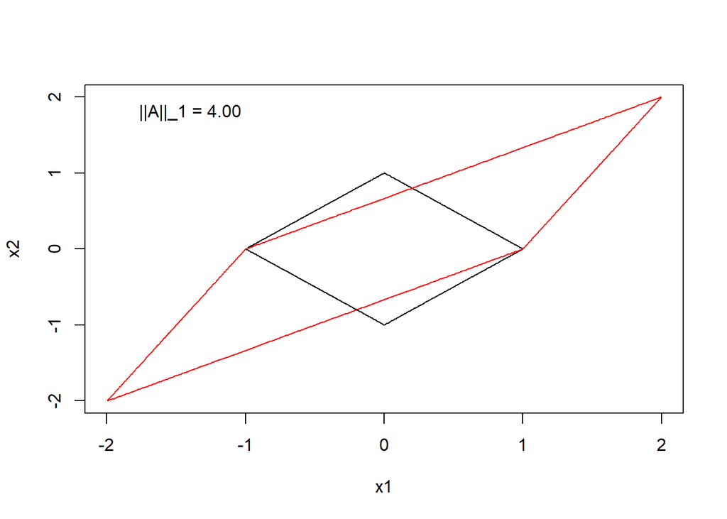

```r
A=cbind(c(1,0),c(2,2))
UnitCircleMap(A,p=1)
```

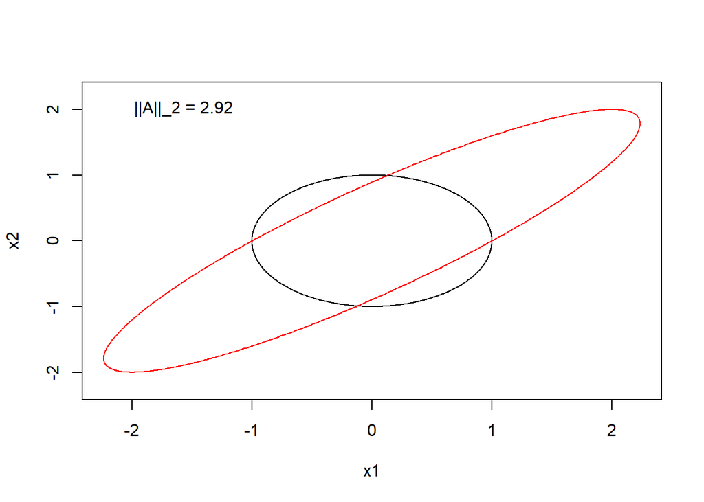

```r
UnitCircleMap(A,p=2)
```

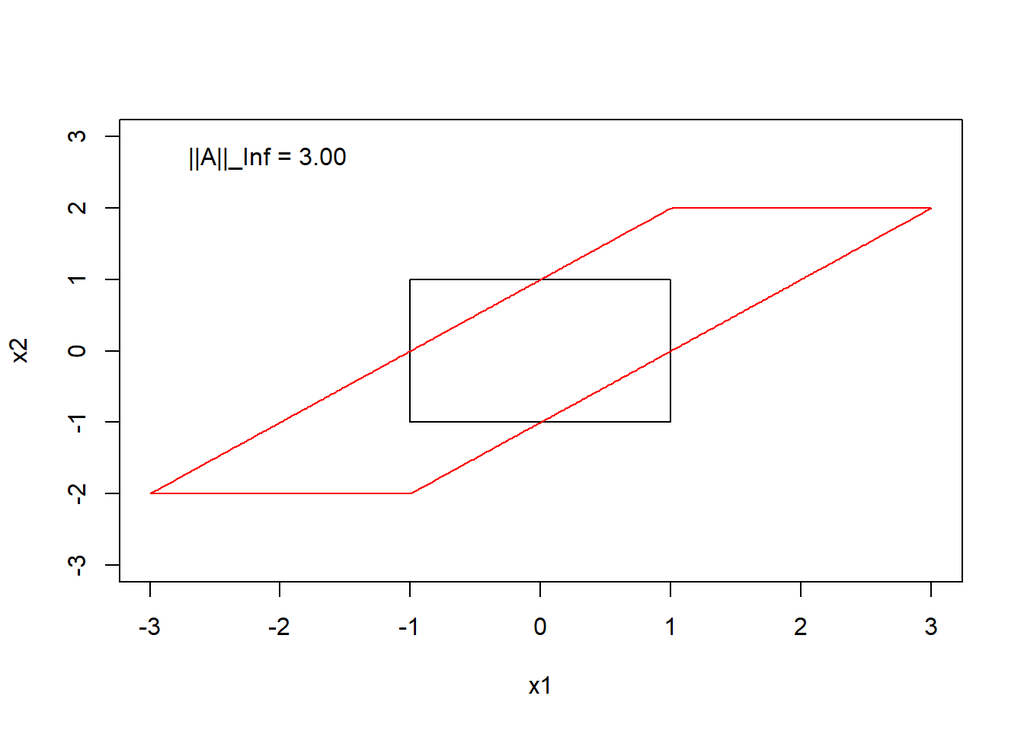

```r
UnitCircleMap(A,p="I")
```

2. Compute the condition number of the matrix $A$ above (using the $p=1,2, \infty$-norms). Visually explain why the condition number for each $p$ is the value you found.

### Solution:

```r
Cond = function(A,p=2) {
  if (p == 2) {  # by default use the
    s = svd(A)$d
    s = s[s>0]
    return(max(s)/min(s))
  }
  if (p == 1) {  # use the 1 norm
    Ainv = solve(A)
    return(max(colSums(abs(A)))*max(colSums(abs(Ainv))))
  }
  if (p == 'I') {   # use the infinity norm
    Ainv = solve(A)
    return(max(rowSums(abs(A)))*max(rowSums(abs(Ainv))))
  }
}



A=cbind(c(1,0),c(2,2))
Cond(A,1)
```

```
## [1] 6
```

```r
Cond(A,2)
```

```
## [1] 4.265564
```

```r
Cond(A,"I")
```

```
## [1] 6
```

```r
##Condition numbers for inverse of A

norm(solve(A),"1")
```

```
## [1] 1.5
```

```r
norm(solve(A),"2")
```

```
## [1] 1.460405
```

```r
norm(solve(A),"I")
```

```
## [1] 2
```

3. Use your code to determine whether $||Q||_1=||Q||_{\infty}=||Q||_2=1$ for all orthonormal matrices $Q$.

**Hint**: Try $Q=\begin{pmatrix} \frac{1}{\sqrt{2}} & \frac{-1}{\sqrt{2}} \\ \frac{1}{\sqrt{2}} & \frac{1}{\sqrt{2}} \end{pmatrix}$, which is a rotation matrix that rotates vectors counter-clockwise by $\frac{\pi}{4}$.

### Solution:

No, $||Q||_1$ and $||Q||_{\infty}$ are not necessarily equal to 1, as demonstrated by the suggested rotation matrix.

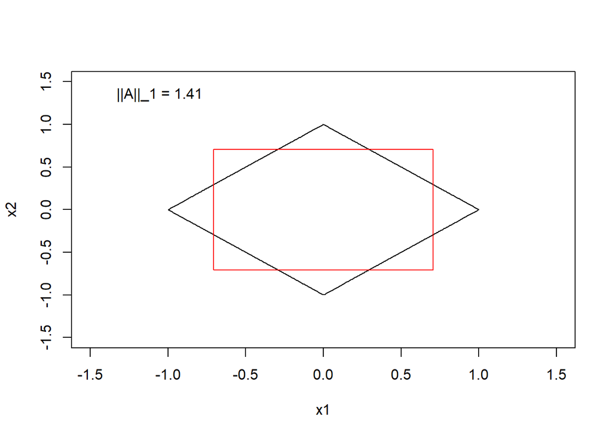

```r
A=cbind(c(1/sqrt(2),1/sqrt(2)),c(-1/sqrt(2),1/sqrt(2)))
UnitCircleMap(A,p=1)
```

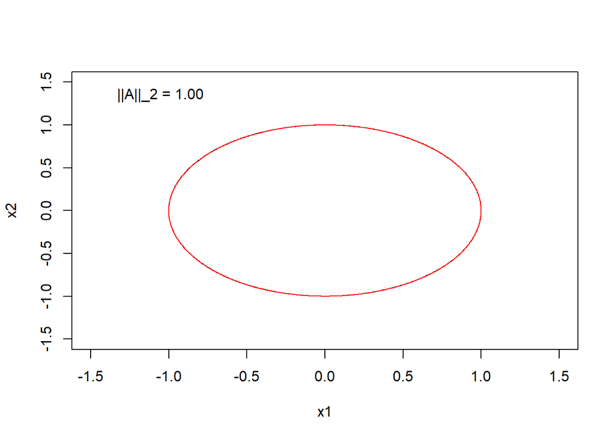

```r
UnitCircleMap(A,p=2)
```

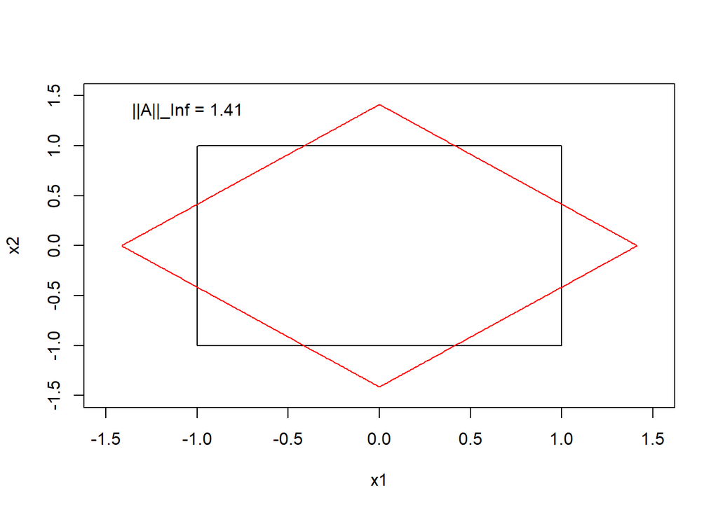

```r
UnitCircleMap(A,p="I")
```

### Problem 6

This was Question 5 on the activity on norms.

Prove that
$$||A||_{\infty}=\max_{1 \leq i \leq n}\left\{ \sum_{j=1}^n |A_{ij}| \right\}=\text{maximum absolute row sum}.$$

### Solution:

We need to show LHS=$||A||_{\infty} \leq \max_{1 \leq i \leq n}\left\{ \sum_{j=1}^n |A_{ij}| \right\}$=RHS and RHS $\leq$ LHS.

Step 1: Show LHS $\leq$ RHS

$$\begin{align*}
||A||_{\infty} &= \max_{||x||_{\infty}=1}||Ax||_{\infty} \text{ (by Question 4 on the activity on norms)} \\
&= \max_{||x||_{\infty}=1} \left\{ \max_{1 \leq i \leq n} |a_i^T x | \right\} \text{ (where } a_i^T \text{ is the i-th row of matrix A)}\\
&= \max_{||x||_{\infty}=1} \left\{ \max_{1 \leq i \leq n} \left| \left\{ \sum_{j=1}^n A_{ij} x_j \right\} \right| \right\} \\
&\leq \max_{||x||_{\infty}=1} \left\{ \max_{1 \leq i \leq n} \sum_{j=1}^n |A_{ij} x_j| \right\} \text{(since taking the absolute value first and then summing is larger than taking the absolute value after summing)} \\
&= \max_{||x||_{\infty}=1} \left\{ \max_{1 \leq i \leq n} \sum_{j=1}^n |A_{ij}| | x_j| \right\}\\
&\leq \max_{||x||_{\infty}=1} \left\{ \max_{1 \leq i \leq n} \sum_{j=1}^n |A_{ij}| \right\} \text{ (since} ||x||_{\infty} \leq 1 \implies |x_j|\leq 1 \text{ for all } j)
\end{align*}$$

Step 2: Show RHS $\leq$ LHS

Let $k= \underset{1 \leq i \leq n}{\operatorname{argmax}} \left\{ \sum_{j=1}^n |A_{ij}| \right\}$. Then $\sum_{j=1}^n |A_{kj}| = \max_{1 \leq i \leq n} |A_{ij}|=\text{maximum row sum.}$ Now, let $y$ be a vector with $y_j = \begin{cases} 1 & \text{ if } A_{kj}\geq 0 \\ -1 & \text{ if } A_{kj} < 0\end{cases}$.

Then,

$$\begin{align*}
\max_{1 \leq i \leq n} |A_{ij}| &=\sum_{j=1}^n |A_{kj}| \\
&=|\sum_{j=1}^n A_{kj} y_j| \text{ (notice signs cancel)} \\
&=a_k^T y \\
&\leq ||A y ||_{\infty} \text{ (since norm is max entry in } Ay \text{ and } a_k^Ty \text{ is just one entry in vector ) Ay} \\
&\leq \max_{||x||_{\infty}=1} ||A x ||_{\infty} \text{ (since } y \subseteq \{x \text{ such that } ||x||_{\infty}=1\} \text{ see Trick 2 on the activity on norms )} \\
&= ||A || _{\infty}
\end{align*}$$

Therefore, LHS $\leq$ RHS and RHS $\leq$ LHS, so
$$||A||_{\infty}=\max_{1 \leq i \leq n}\left\{ \sum_{j=1}^n |A_{ij}| \right\}=\text{maximum absolute row sum}.$$

### Problem 7

Solve the following system by finding the $PA=LU$ factorization and then carrying out the two-step back substitution (all by hand):

$$A=\begin{pmatrix}-1 & 0 & 1 \\
3 & 1 & 1 \\
2 & 0 & 1
\end{pmatrix} \begin{pmatrix} x_1 \\ x_2\\ x_3\end{pmatrix}=\begin{pmatrix} 2 \\ 5 \\ 5 \end{pmatrix}.$$

### Solution:

First, let $U=A$ and we will keep a matrix $P=I$ for all of the permutations. Let’s exchange the first two rows, so that 3 is the pivot:
$$U = \begin{pmatrix}
3 & 1 & 1 \\
-1 & 0 & 1 \\
2 & 0 & 1
\end{pmatrix} \qquad P = \begin{pmatrix}0 & 1 & 0 \\
1 & 0 & 0 \\
0 & 0 & 1
\end{pmatrix}$$
Next we eliminate the first column and store the multipliers in $L=I$:
$$U=
\begin{pmatrix}
3 & 1 & 1 \\
0 & \frac{1}{3} & \frac{4}{3} \\
0 & -\frac{2}{3} & \frac{1}{3}
\end{pmatrix} \qquad L=
\begin{pmatrix}
1 & 0 & 0 \\
-\frac{1}{3} & 1 & 0 \\
\frac{2}{3} & 0 & 1
\end{pmatrix}
\qquad P = \begin{pmatrix}0 & 1 & 0 \\
1 & 0 & 0 \\
0 & 0 & 1
\end{pmatrix}$$
Now we exchange the second and third rows to get the $-2/3$ in $U$ to be the pivot, making sure to also exchange the below diagonal elements in the corresponding rows in $L$:
$$U=
\begin{pmatrix}
3 & 1 & 1 \\
0 & -\frac{2}{3} & \frac{1}{3} \\
0 & \frac{1}{3} & \frac{4}{3}
\end{pmatrix} \qquad
L=
\begin{pmatrix}
1 & 0 & 0 \\
\frac{2}{3} & 1 & 0 \\
-\frac{1}{3} & 0 & 1
\end{pmatrix}
\qquad
P = \begin{pmatrix}0 & 1 & 0 \\
0 & 0 & 1 \\
1 & 0 & 0
\end{pmatrix}$$
Now we eliminate the second column:
$$U=\begin{pmatrix}
3 & 1 & 1 \\
0 & -\frac{2}{3} & \frac{1}{3} \\
0 & 0 & 1.5
\end{pmatrix}
\qquad
L=
\begin{pmatrix}
1 & 0 & 0 \\
\frac{2}{3} & 1 & 0 \\
-\frac{1}{3} & -\frac{1}{2} & 1
\end{pmatrix}
\qquad
P = \begin{pmatrix}0 & 1 & 0 \\
0 & 0 & 1 \\
1 & 0 & 0
\end{pmatrix}$$

Let’s check our computations in R:

```r
P=rbind(c(0,1,0),c(0,0,1),c(1,0,0))
L=rbind(c(1,0,0),c(2/3,1,0),c(-1/3,-1/2,1))
U=rbind(c(3,1,1),c(0,-2/3,1/3),c(0,0,1.5))
A=rbind(c(-1,0,1),c(3,1,1),c(2,0,1))
P%*%A
```

```
##      [,1] [,2] [,3]
## [1,]    3    1    1
## [2,]    2    0    1
## [3,]   -1    0    1
```

```r
L%*%U
```

```
##      [,1] [,2] [,3]
## [1,]    3    1    1
## [2,]    2    0    1
## [3,]   -1    0    1
```

Next, we need to do the back-substitutions, starting with $PLy=Pb$:
$$\begin{pmatrix}
1 & 0 & 0 \\
\frac{2}{3} & 1 & 0 \\
-\frac{1}{3} & -\frac{1}{2} & 1
\end{pmatrix} \begin{pmatrix}~ \\ y \\ ~ \end{pmatrix} =
\begin{pmatrix}5 \\ 5 \\ 2 \end{pmatrix} \Rightarrow y=\begin{pmatrix}5 \\ \frac{5}{3} \\ \frac{9}{2} \end{pmatrix}.$$
Finally, we solve $Ux=y$:
$$\begin{pmatrix}
3 & 1 & 1 \\
0 & -\frac{2}{3} & \frac{1}{3} \\
0 & 0 & 1.5
\end{pmatrix} \begin{pmatrix}~ \\ x \\ ~ \end{pmatrix} =
\begin{pmatrix}5 \\ \frac{5}{3} \\ \frac{9}{2} \end{pmatrix} \Rightarrow x = \begin{pmatrix} 1\\-1\\3 \end{pmatrix}.$$
Let’s double check our answer:

```r
b=rbind(2,5,5)
solve(A,b)
```

```
##      [,1]
## [1,]    1
## [2,]   -1
## [3,]    3
```